# HW1

Anish Mohan

January 25, 2016

1. Q1
- 1a.
  - Scenario: Is school rating more important than Real-Estate-Factors for the value of house value
    - Response: Sale value of a house
    - Predictors: # of bedrooms, bathrooms, size, location, rating of school, football program in school etc.
    - Goal: Inference because goal is to find if the rating of the school has more impact than other predictors
  - Scenario: Weather of a particular place in January-2017
    - Response: Temperature of a particular place
    - Predictors: Lat/Long of the place, time of day, day of the year, temperature previous year etc.
    - Goal: Prediction because we are trying to use the predictors to predict the weather in future.
  - Scenario: Sales and impact of Internet Advertising.
    - Response: Volume sales
    - Predictors: Advertising in various media channels: radio, newspaper, tv and internet.
    - Goal: Inference, as are trying to find if advertising on interet has more siginificant impact than other mediums.
- 1b.
  - Given certain measurements of fish samples, categorizing them into different species/classes. This is an unsupervised learning problem as no labels are given.
  - Given a bunch of pictures of different pose of different animals, catergorize the pictures. Since no labels are given, this would be an unsupervised learning.
  - Given writing samples of words from various languages, clustering the words that belong to same script together. Again, since the input is just a collection of written scripts without labels, this is an unsupervised learning problem.
- 1c.
  - Certain measurements of fish samples are given; Classifying the fish into different species/classes based on sample measurements.
  - Pictures of various animals in different poses are given. Classify the pictures into various categories of animals.
  - Writing samples of words from various languages are given; classifying the words of the sample into their respective languages.
2. Q2
- 2a.
  - Classifcation problem
  - n=42000
  - p=6 (age, high school GPA, SAT reading score, SAT Math Score, SAT writing score, Domestic/Iterntion)
- 2b.
  - Unsupervised learning problem
  - n=200
  - p=3 (age, zip code gender)
- 2c.
  - Regression problem
  - n=500
  - p=6 (population, state, avg income, crime rate, high school passed students, unemployment level)
- 2d.
  - Supervised learning problem as training sample and labels are provided.
  - Prediction because the neuroscientist in interested in predicting the cell types based on measurements.
  - n=48
  - p=3 (# of branch points, # of active processes, avg process length)
3. Q3
- 3a.
  - Advantages of less flexible
  - Works well if the true function is very simple (e.g linear)
  - Generally does not have the problem of overfitting.
  - Fewer number of parameters to learn hence does not need a large number of learning samples
  - Less Flexible method will better than flexible models when there are large number of predictors and few sample points.
  - Less flexible methods are better when the data has lot of variance or noise.
  - Disadvantages of less flexible
  - Does not work well if the true function is not simple (e.g non-linear).
  - Cannot effectively use a large dataset to model complex functions.
- 3b. Non-Flexible approach is better than a flexible method
  - Problem with large number of predictors and few sample points
  - An inflexible model will generally find a better fit to combine the predictors to produce the results close to the few samples. With large number of predictors and few number of sample points, the flexible model will combine the predictors but will be constrainted to the small number of existing data points, thus overfitting the limited data.
- Given data has high variance and noise.
  - Given the high variance in noise, flexible models will tend to fit the error data and give poor results. Inflexible models will do a better job of ignoring the noise and finding a reasonable fit
- 3c. Flexible approach is better than a non-flexible method
  - Given dataset with the underlying function being highly non-linear and sufficient amount of data.
  - Inflexible models cannot generalize for non linear functions. Flexible models will have better ability to fit to non-linear models, hence they will generally perform better
  - Given dataset with small number of predictors and large number of sample.
  - Inflexible methods can only fit to specific combination (e.g linear combination) of the small number of predictors and cannot utlize the large number of samples to find a good fitting model. However, if the underlying function is linear, then the inflexible method will do well. Flexible learning methods will be able to utlize the large number of samples to find a reasonable fit for the true function with p predictors. However, there is a risk of over fitting the large number of input training points.
4. Q4
- 4a.

```r
library(MASS)
dim(Boston)
```

```
## [1] 506  14
```

[output not shown]

- 4b.

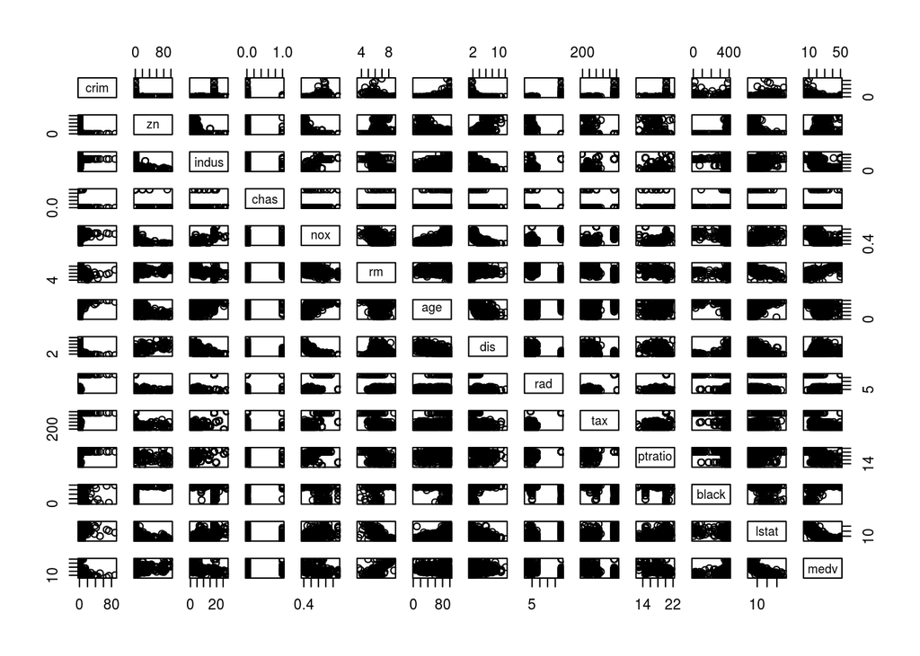

```r
pairs(Boston)
```

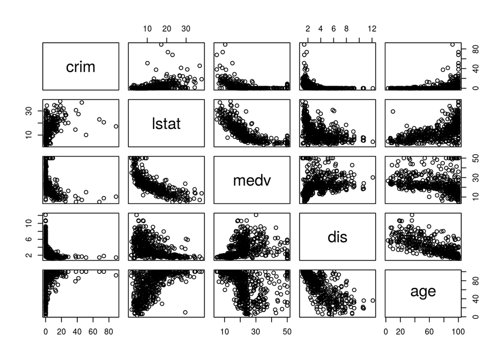

```
+ Some of predictors of the per capita crime rates are medv(median house value), lstat(% of lower stat poputlation), dis (% disance away from employment center).

+ Crime rate is very high in the areas with lower median value and decreases exponentially in the areas where the median house values are larger. Inverse relationship between crime rate and median value of house.

+ Crime rate is very high in the areas that are nearer to the employment centers. Crime rate decreases as we move away from the employment areas. Again an inverse relationship between crime rate and weighted distance to employment center.

+ Crime rate is lower in areas where there smaller percentage of lower status population. There is postive correlation between the percent of lower status population and the crime rate.
```

```r
pairs(~crim+lstat+medv+dis+age,Boston)
```

- 4d

```r
max(Boston$crim)
```

```
## [1] 88.9762
```

```r
which.max(Boston$crim)
```

```
## [1] 381
```

```r
summary(Boston$crim)
```

```
##     Min.  1st Qu.   Median     Mean  3rd Qu.     Max.
##  0.00632  0.08204  0.25650  3.61400  3.67700 88.98000
```

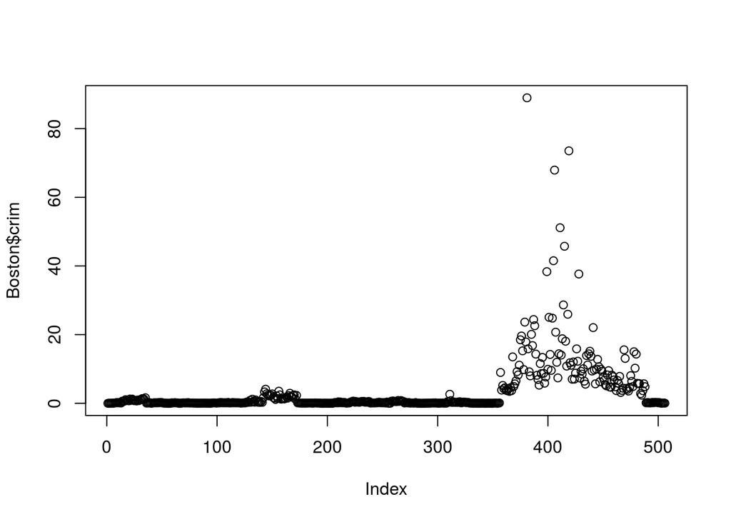

```r
plot(Boston$crim)
```

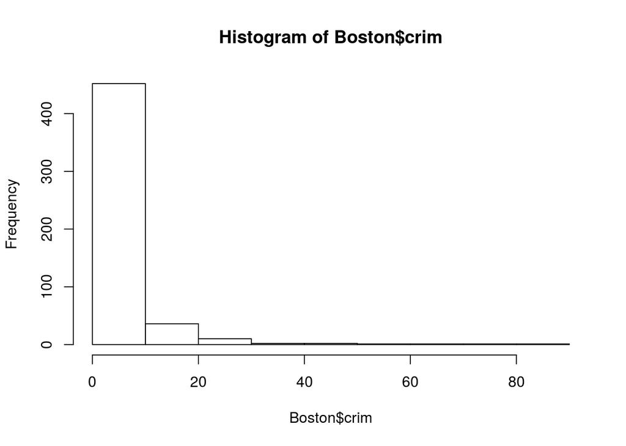

```r
hist(Boston$crim)
```

```r
length(which(Boston$crim>10))
```

```
## [1] 54
```

```
+ Per capita crime rate is the highest at ~89 in suburb with index #381.
+ Per capita crime rate varies from 0.006 to 88.98, with median being 0.256 and mean being 3.614
+ 54 suburbs have crime rate >10. Most of the suburbs have low per capita crime rate.
```

```r
max(Boston$tax)
```

```
## [1] 711
```

```r
which.max(Boston$tax)
```

```
## [1] 489
```

```r
summary(Boston$tax)
```

```
##    Min. 1st Qu.  Median    Mean 3rd Qu.    Max.
##   187.0   279.0   330.0   408.2   666.0   711.0
```

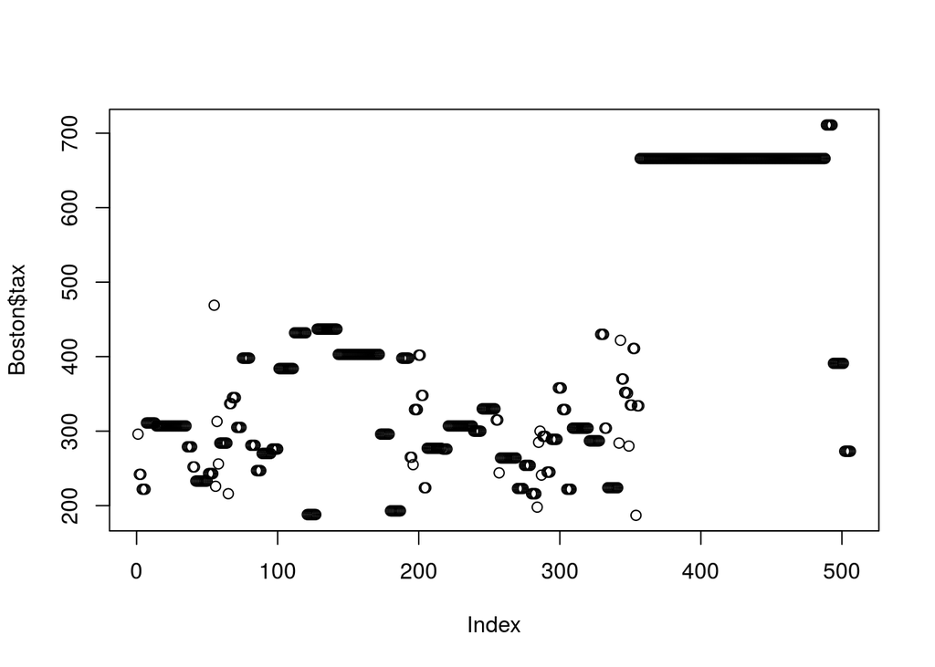

```r
plot(Boston$tax)
```

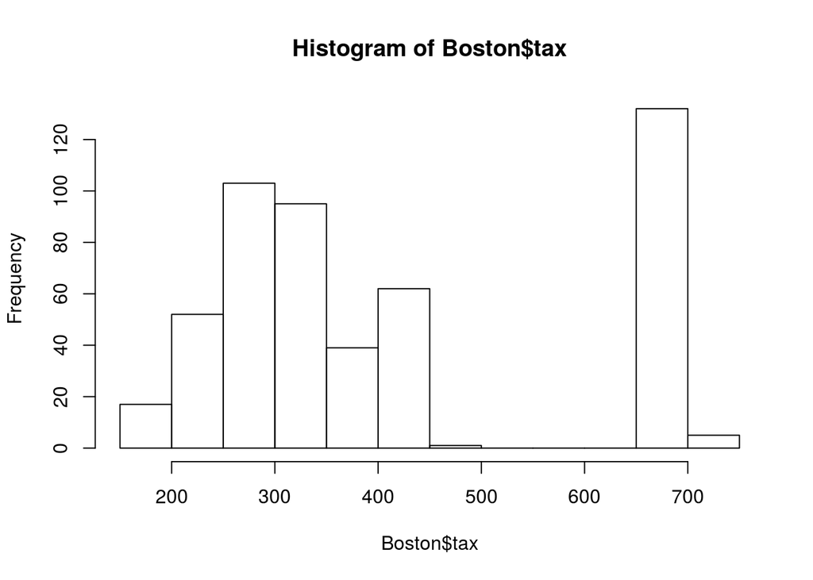

```r
hist(Boston$tax)
```

```r
length(which(Boston$tax>500))
```

```
## [1] 137
```

- Max tax rate (per $10000) is $711 in the boston suburb with index 489
- Tax rate varies from $187 to $711 (for per $10000)
- 137 suburbs have a tax rate > $500 (per $10000)

```r
max(Boston$ptratio)
```

```
## [1] 22
```

```r
which.max(Boston$ptratio)
```

```
## [1] 355
```

```r
summary(Boston$ptratio)
```

```
##    Min. 1st Qu.  Median    Mean 3rd Qu.    Max.
##   12.60   17.40   19.05   18.46   20.20   22.00
```

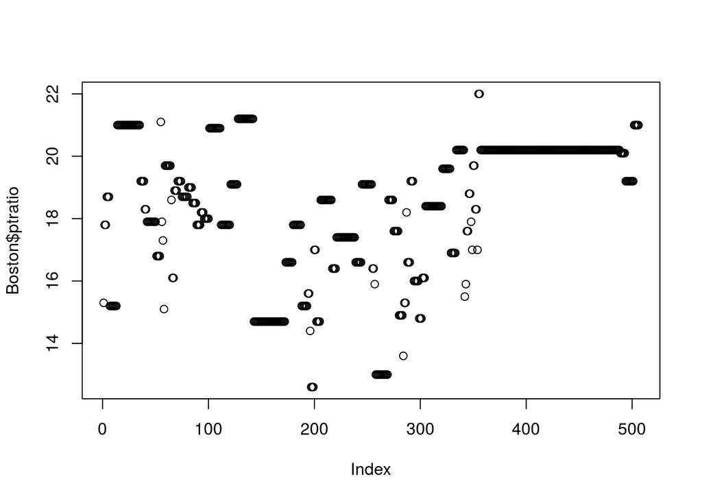

```r
plot(Boston$ptratio)
```

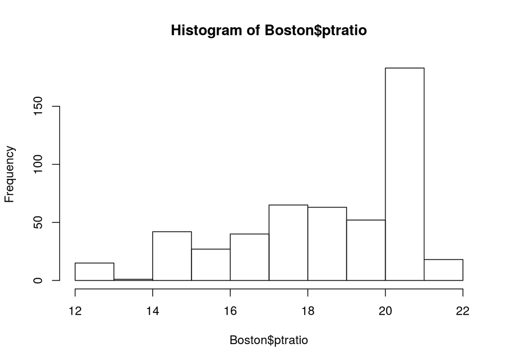

```r
hist(Boston$ptratio)
```

```r
length(which(Boston$ptratio>20))
```

```
## [1] 201
```

- Maximum pupil/teacher ratio is 22 in suburb with index 355.
- pupil teacher ratio varies from 12.60 to 22.00.
- 201 suburbs have the pupil/teacher ration >20.
- 4e.

```r
length(which(Boston$chas==1))
```

```
## [1] 35
```

- There are 35 suburbs that are bound to Charles river
- 4f.

```r
summary(Boston$ptratio)
```

```
##    Min. 1st Qu.  Median    Mean 3rd Qu.    Max.
##   12.60   17.40   19.05   18.46   20.20   22.00
```

- Median ptratio in Boston data set is 19.05